# Original Study: Data Analysis

Hypothesis 6

```r
#by-subject_id varying intercepts and varying
#slope, without slope/intercept correlation
#by-exemplar varying intercept
model_hypo6 = brm(
  initiation_time ~ trial_type +
    (trial_type || subject_id)+
    (1 |exemplar),
  control=list(adapt_delta=0.99, max_treedepth=15),
  data = animal
  )


model_hypo6
```

```
##  Family: gaussian
##   Links: mu = identity; sigma = identity
## Formula: initiation_time ~ trial_type + (trial_type || subject_id) + (1 | exemplar)
##    Data: animal (Number of observations: 598)
## Samples: 4 chains, each with iter = 2000; warmup = 1000; thin = 1;
##          total post-warmup samples = 4000
##
## Group-Level Effects:
## ~exemplar (Number of levels: 15)
##               Estimate Est.Error l-95% CI u-95% CI Rhat Bulk_ESS Tail_ESS
## sd(Intercept)   162.17     68.41    33.76   311.71 1.00      912      770
##
## ~subject_id (Number of levels: 53)
##                       Estimate Est.Error l-95% CI u-95% CI Rhat Bulk_ESS
## sd(Intercept)           676.55     77.47   539.62   843.58 1.00     1346
## sd(trial_typeTypical)    91.53     68.69     3.66   254.16 1.00     1075
##                       Tail_ESS
## sd(Intercept)             1703
## sd(trial_typeTypical)     1803
##
## Population-Level Effects:
##                   Estimate Est.Error l-95% CI u-95% CI Rhat Bulk_ESS Tail_ESS
## Intercept           622.93    140.47   348.20   895.42 1.00     1479     2119
## trial_typeTypical  -112.86    123.06  -354.46   135.58 1.00     3125     2969
##
## Family Specific Parameters:
##       Estimate Est.Error l-95% CI u-95% CI Rhat Bulk_ESS Tail_ESS
## sigma   817.55     25.71   768.77   870.31 1.00     4588     3168
##
## Samples were drawn using sampling(NUTS). For each parameter, Bulk_ESS
## and Tail_ESS are effective sample size measures, and Rhat is the potential
## scale reduction factor on split chains (at convergence, Rhat = 1).
```

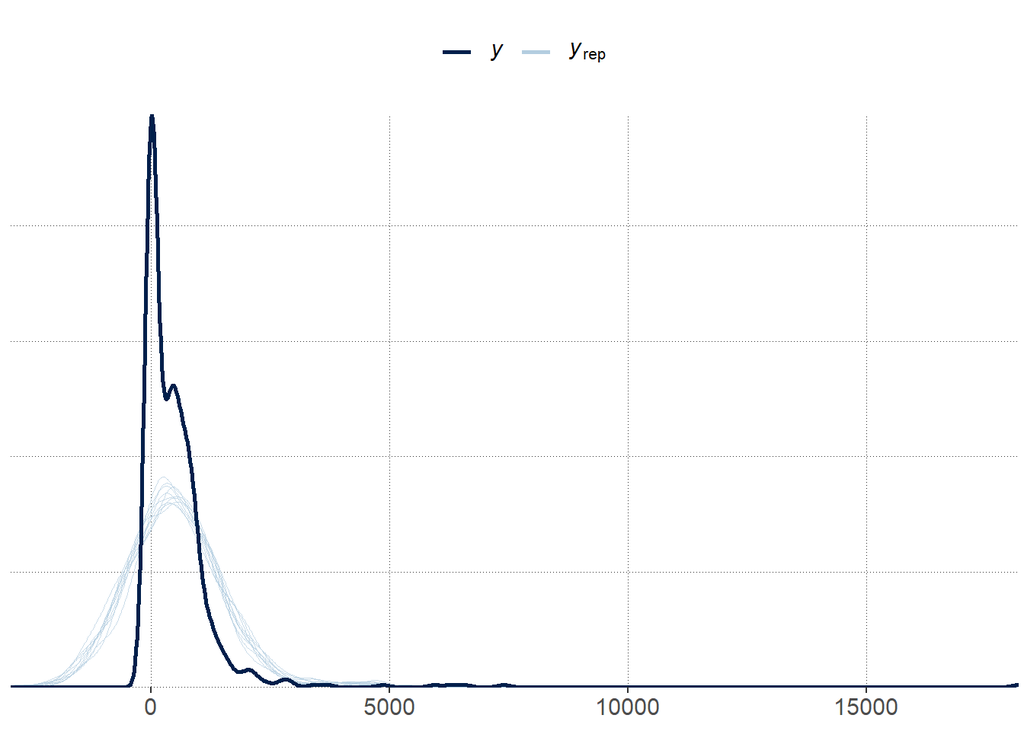

```r
#fitting the model to the actual data
pp_check(model_hypo6)
```

```r
# Extract the posteriors
posteriors6_trial_type <- model_hypo6 %>%
  spread_draws(b_Intercept,
               b_trial_typeTypical) %>%
  # calculate posteriors for each individual level
  mutate(Atypical = b_Intercept,
         Typical = b_Intercept + b_trial_typeTypical) %>%
  select(Atypical, Typical) %>%
  gather(key = "parameter", value = "posterior") %>%
  group_by(parameter) %>%
  summarise(mean_posterior = mean(posterior),
            `95lowerCrI` = HDInterval::hdi(posterior, credMass = 0.90)[1],
            `95higherCrI` = HDInterval::hdi(posterior, credMass = 0.90)[2])

posteriors6_trial_type
```

```
## # A tibble: 2 x 4
##   parameter mean_posterior `95lowerCrI` `95higherCrI`
##   <chr>              <dbl>        <dbl>         <dbl>
## 1 Atypical            623.         384.          843.
## 2 Typical             510.         316.          699.
```

```r
# Extract the posteriors
posteriors6 <- model_hypo6 %>%
  spread_draws(b_trial_typeTypical) %>%
  select(b_trial_typeTypical) %>%
  gather(key = "parameter", value = "posterior")


posteriors6
```

```
## # A tibble: 4,000 x 2
##    parameter           posterior
##    <chr>                   <dbl>
##  1 b_trial_typeTypical    125.
##  2 b_trial_typeTypical   -215.
##  3 b_trial_typeTypical   -136.
##  4 b_trial_typeTypical   -211.
##  5 b_trial_typeTypical     78.7
##  6 b_trial_typeTypical   -137.
##  7 b_trial_typeTypical     -5.88
##  8 b_trial_typeTypical   -106.
##  9 b_trial_typeTypical   -162.
## 10 b_trial_typeTypical   -390.
## # ... with 3,990 more rows
```

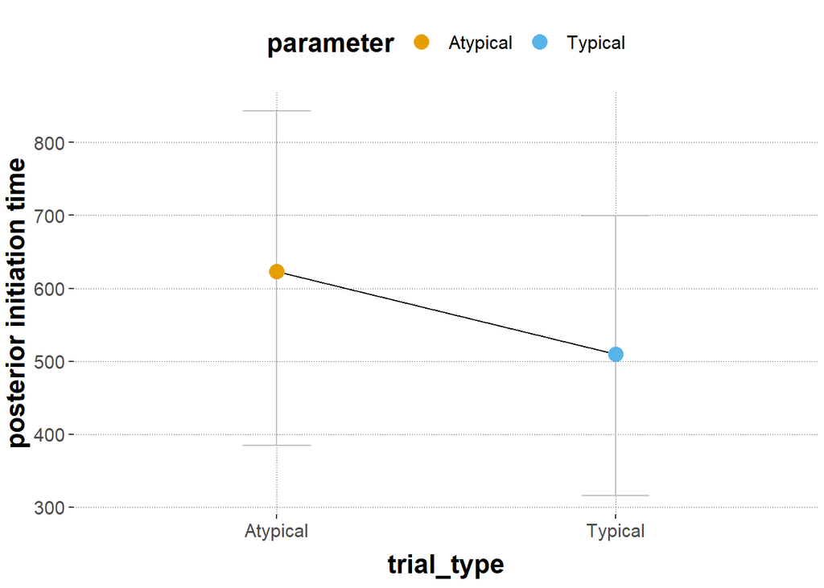

```r
# plot
ggplot(data = posteriors6_trial_type,
       aes(x = parameter, y = mean_posterior,
           color = parameter, fill = parameter)) +
  geom_errorbar(aes(ymin = `95lowerCrI`, ymax = `95higherCrI`),
                width = 0.2, color = "grey") +
  geom_line(aes(group = 1), color = "black") +
  geom_point(size = 4) +
  labs(x = "trial_type",
       y = "posterior initiation time")
```

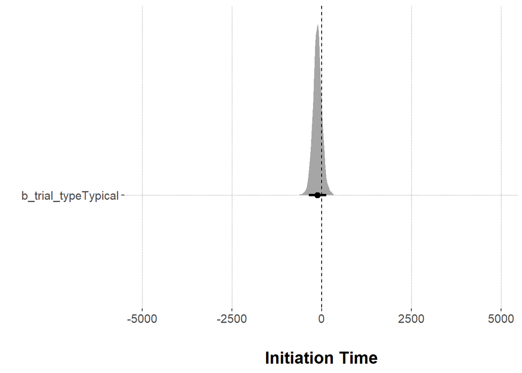

```r
# plot the regression coefficients
  ggplot(posteriors6, aes(x = posterior, y = parameter)) +
    # plot density
    geom_halfeyeh(.width = 0.95) +
    # add axes titles
    xlab("\nInitiation Time") +
    ylab("") +
    # adjust the x-axis
    scale_x_continuous(limits = c(-5000,5000)) +
    # add line for the value zero
    geom_segment(x = 0, xend = 0, y = Inf, yend = -Inf,
                 lty = "dashed")
```

Hypothese 7

```r
animal$traveledDistance_abs <- abs(animal$traveledDistance)

#informative prior
prior_hypo7 <- c(
  #prior for the Intercept
  set_prior("student_t(3, 50,20)", class = "Intercept"),
  #prior for all SDs including the varying intercepts and slopes
  set_prior("student_t(3, 0, 20)", class = "sd"),
  set_prior("student_t(3, 0, 20)", class = "sigma")
)

#by-subject_id varying intercepts and varying
#slope, without slope/intercept correlation
#by-exemplar varying intercept
model_hypo7 = brm(
  traveledDistance_abs ~ trial_type +
    (trial_type || subject_id)+
    (1 |exemplar),
  control=list(adapt_delta=0.99, max_treedepth=15),
  data = animal,
  prior = prior_hypo7
  )


model_hypo7
```

```
##  Family: gaussian
##   Links: mu = identity; sigma = identity
## Formula: traveledDistance_abs ~ trial_type + (trial_type || subject_id) + (1 | exemplar)
##    Data: animal (Number of observations: 598)
## Samples: 4 chains, each with iter = 2000; warmup = 1000; thin = 1;
##          total post-warmup samples = 4000
##
## Group-Level Effects:
## ~exemplar (Number of levels: 15)
##               Estimate Est.Error l-95% CI u-95% CI Rhat Bulk_ESS Tail_ESS
## sd(Intercept)     2.67      1.52     0.19     5.96 1.00     1175     1347
##
## ~subject_id (Number of levels: 53)
##                       Estimate Est.Error l-95% CI u-95% CI Rhat Bulk_ESS
## sd(Intercept)            45.80      4.72    37.75    56.20 1.01      783
## sd(trial_typeTypical)     7.61      3.80     0.75    14.89 1.00      621
##                       Tail_ESS
## sd(Intercept)             1741
## sd(trial_typeTypical)     1009
##
## Population-Level Effects:
##                   Estimate Est.Error l-95% CI u-95% CI Rhat Bulk_ESS Tail_ESS
## Intercept            72.39      6.53    59.39    84.86 1.01      460     1096
## trial_typeTypical   -11.13      2.91   -16.83    -5.29 1.00     4454     3351
##
## Family Specific Parameters:
##       Estimate Est.Error l-95% CI u-95% CI Rhat Bulk_ESS Tail_ESS
## sigma    21.31      0.69    19.98    22.70 1.00     2798     2572
##
## Samples were drawn using sampling(NUTS). For each parameter, Bulk_ESS
## and Tail_ESS are effective sample size measures, and Rhat is the potential
## scale reduction factor on split chains (at convergence, Rhat = 1).
```

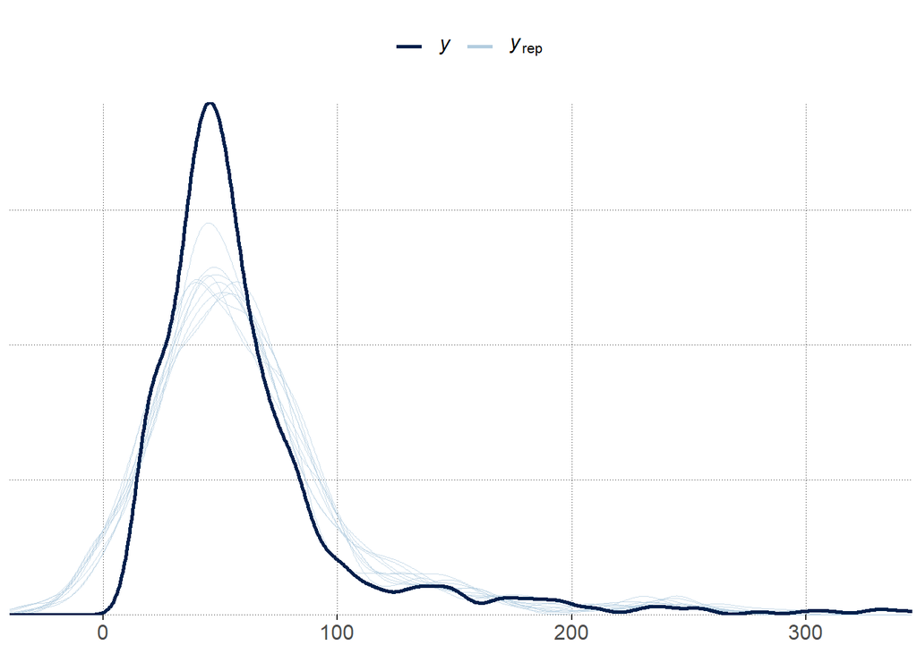

```r
#fitting the model to the actual data
pp_check(model_hypo7)
```

```r
# Extract the posteriors
posteriors7_trial_type <- model_hypo7 %>%
  spread_draws(b_Intercept,
               b_trial_typeTypical) %>%
  # calculate posteriors for each individual level
  mutate(Atypical = b_Intercept,
         Typical = b_Intercept + b_trial_typeTypical) %>%
  select(Atypical, Typical) %>%
  gather(key = "parameter", value = "posterior") %>%
  group_by(parameter) %>%
  summarise(mean_posterior = mean(posterior),
            `95lowerCrI` = HDInterval::hdi(posterior, credMass = 0.90)[1],
            `95higherCrI` = HDInterval::hdi(posterior, credMass = 0.90)[2])

posteriors7_trial_type
```

```
## # A tibble: 2 x 4
##   parameter mean_posterior `95lowerCrI` `95higherCrI`
##   <chr>              <dbl>        <dbl>         <dbl>
## 1 Atypical            72.4         61.6          83.1
## 2 Typical             61.3         51.0          71.6
```

```r
# Extract the posteriors
posteriors7 <- model_hypo7 %>%
  spread_draws(b_trial_typeTypical) %>%
  select(b_trial_typeTypical) %>%
  gather(key = "parameter", value = "posterior")


posteriors7
```

```
## # A tibble: 4,000 x 2
##    parameter           posterior
##    <chr>                   <dbl>
##  1 b_trial_typeTypical    -13.0
##  2 b_trial_typeTypical    -12.4
##  3 b_trial_typeTypical    -15.0
##  4 b_trial_typeTypical    -14.1
##  5 b_trial_typeTypical     -8.79
##  6 b_trial_typeTypical    -10.4
##  7 b_trial_typeTypical    -12.2
##  8 b_trial_typeTypical    -11.7
##  9 b_trial_typeTypical    -14.4
## 10 b_trial_typeTypical    -12.3
## # ... with 3,990 more rows
```

```r
posterior7_agg <- posteriors7 %>%
  mutate(mean_posterior = mean(posterior))

posterior7_agg
```

```
## # A tibble: 4,000 x 3
##    parameter           posterior mean_posterior
##    <chr>                   <dbl>          <dbl>
##  1 b_trial_typeTypical    -13.0           -11.1
##  2 b_trial_typeTypical    -12.4           -11.1
##  3 b_trial_typeTypical    -15.0           -11.1
##  4 b_trial_typeTypical    -14.1           -11.1
##  5 b_trial_typeTypical     -8.79          -11.1
##  6 b_trial_typeTypical    -10.4           -11.1
##  7 b_trial_typeTypical    -12.2           -11.1
##  8 b_trial_typeTypical    -11.7           -11.1
##  9 b_trial_typeTypical    -14.4           -11.1
## 10 b_trial_typeTypical    -12.3           -11.1
## # ... with 3,990 more rows
```

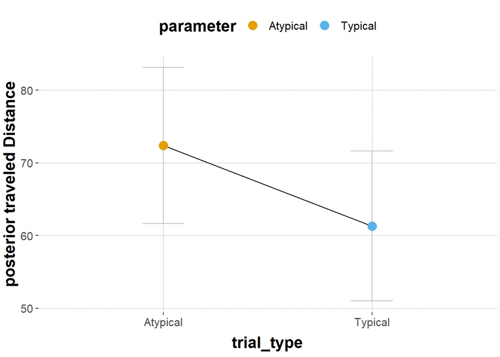

```r
# plot
ggplot(data = posteriors7_trial_type,
       aes(x = parameter, y = mean_posterior,
           color = parameter, fill = parameter)) +
  geom_errorbar(aes(ymin = `95lowerCrI`, ymax = `95higherCrI`),
                width = 0.2, color = "grey") +
  geom_line(aes(group = 1), color = "black") +
  geom_point(size = 4) +
  labs(x = "trial_type",
       y = "posterior traveled Distance")
```

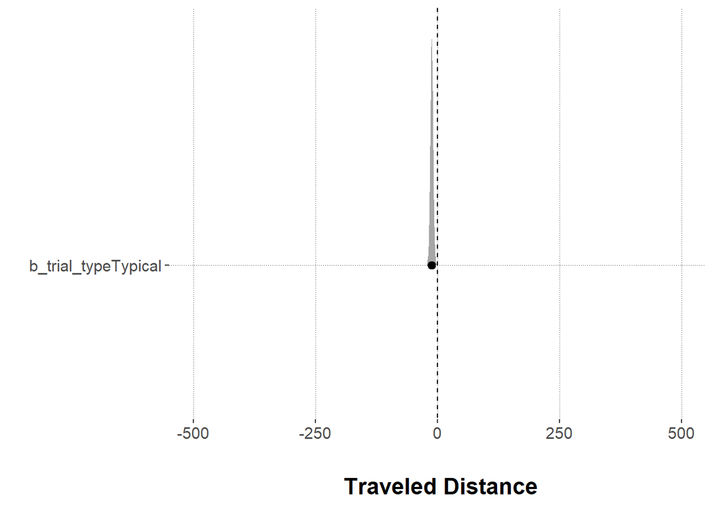

```r
# plot the regression coefficients
  ggplot(posteriors7, aes(x = posterior, y = parameter)) +
    # plot density
    geom_halfeyeh(.width = 0.95) +
    # add axes titles
    xlab("\n Traveled Distance") +
    ylab("") +
    # adjust the x-axis
    scale_x_continuous(limits = c(-500,500)) +
    # add line for the value zero
    geom_segment(x = 0, xend = 0, y = Inf, yend = -Inf,
                 lty = "dashed")
```

```r
#computing evidential ratio and posterior probability
hypothesis(model_hypo7, "trial_typeTypical > -11.06")
```

```
## Hypothesis Tests for class b:
##                 Hypothesis Estimate Est.Error CI.Lower CI.Upper Evid.Ratio
## 1 (trial_typeTypica... > 0    -0.07      2.91    -4.86     4.75       0.95
##   Post.Prob Star
## 1      0.49
## ---
## 'CI': 90%-CI for one-sided and 95%-CI for two-sided hypotheses.
## '*': For one-sided hypotheses, the posterior probability exceeds 95%;
## for two-sided hypotheses, the value tested against lies outside the 95%-CI.
## Posterior probabilities of point hypotheses assume equal prior probabilities.
```

Results: The mean posterior traveled distance values are higher for Atypical than Typical trial types, due to the negative slope going from the reference level (Atypical) to the Typical trial type. The credible interval of the coefficient trial_typeTypical does not include 0, wherefore there is evidence for the hypothesis to hold true. The evidence ratio is 1. and the posterior probability is 50%. This means that the strength of evidence is barely worth mentioning.